# SCEM Assignment 3

Max Kirwan

13/10/2021

## 1. Random experiments, events and sample spaces

A $\bf{random}$ $\bf{experiment}$ is a procedure which has a well defined set of outcomes and which (in theory) could be repeated arbitrarily many times.

An $\bf{event}$ is a set of possible outcomes and the $\bf{sample}$ $\bf{space}$ is the set of all possible outcomes of interest for a random experiment.

## 2. Tidy data and iteration

#### 2.1 Missing data and iteration

```r
library(tidyverse)
```

```r
impute_by_mean<-function(x){
  mu<-mean(x,na.rm=1) # first compute the mean of x
  impute_f<-function(z){ # coordinate-wise imputation
    if(is.na(z)){
      return(mu) # if z is na replace with mean
    }
    else{
      return(z) # otherwise leave in place
    }
  }
  return(map_dbl(x,impute_f)) # apply the map function to impute across vector
}

impute_by_median<-function(x){
  mu<-median(x,na.rm=1) # first compute the median of x
  impute_f<-function(z){ # coordinate-wise imputation
    if(is.na(z)){
      return(mu) # if z is na replace with mean
    }
    else{
      return(z) # otherwise leave in place
    }
  }
  return(map_dbl(x,impute_f)) # apply the map function to impute across vector
}

v <- c(1,2,NA,4)
impute_by_mean(v)
```

```
## [1] 1.000000 2.000000 2.333333 4.000000
```

```r
impute_by_median(v)
```

```
## [1] 1 2 2 4
```

```r
x <- seq(from=0, to=10, by=0.1)
y <- 5*x+1
df_xy <- data.frame(x,y)
head(df_xy)
```

```
##     x   y
## 1 0.0 1.0
## 2 0.1 1.5
## 3 0.2 2.0
## 4 0.3 2.5
## 5 0.4 3.0
## 6 0.5 3.5
```

```r
 df_xy%>%
  mutate(z=map2_dbl(x,y,~.x+.y))%>%
  head(5)
```

```
##     x   y   z
## 1 0.0 1.0 1.0
## 2 0.1 1.5 1.6
## 3 0.2 2.0 2.2
## 4 0.3 2.5 2.8
## 5 0.4 3.0 3.4
```

```r
sometimes_missing <- function(index,value){
  if(index%%5==0){return(NA)}
  else{return(value)}
}
sometimes_missing(14,25)
```

```
## [1] 25
```

```r
sometimes_missing(15,25)
```

```
## [1] NA
```

```r
df_xy_missing <- df_xy %>%
  mutate(y=map2_dbl(row_number(),y,sometimes_missing))
df_xy_missing %>% head(10)
```

```
##      x   y
## 1  0.0 1.0
## 2  0.1 1.5
## 3  0.2 2.0
## 4  0.3 2.5
## 5  0.4  NA
## 6  0.5 3.5
## 7  0.6 4.0
## 8  0.7 4.5
## 9  0.8 5.0
## 10 0.9  NA
```

```r
df_xy_imputed <- df_xy_missing %>%
  mutate(y=impute_by_median(y))
df_xy_imputed %>% head(10)
```

```
##      x    y
## 1  0.0  1.0
## 2  0.1  1.5
## 3  0.2  2.0
## 4  0.3  2.5
## 5  0.4 26.0
## 6  0.5  3.5
## 7  0.6  4.0
## 8  0.7  4.5
## 9  0.8  5.0
## 10 0.9 26.0
```

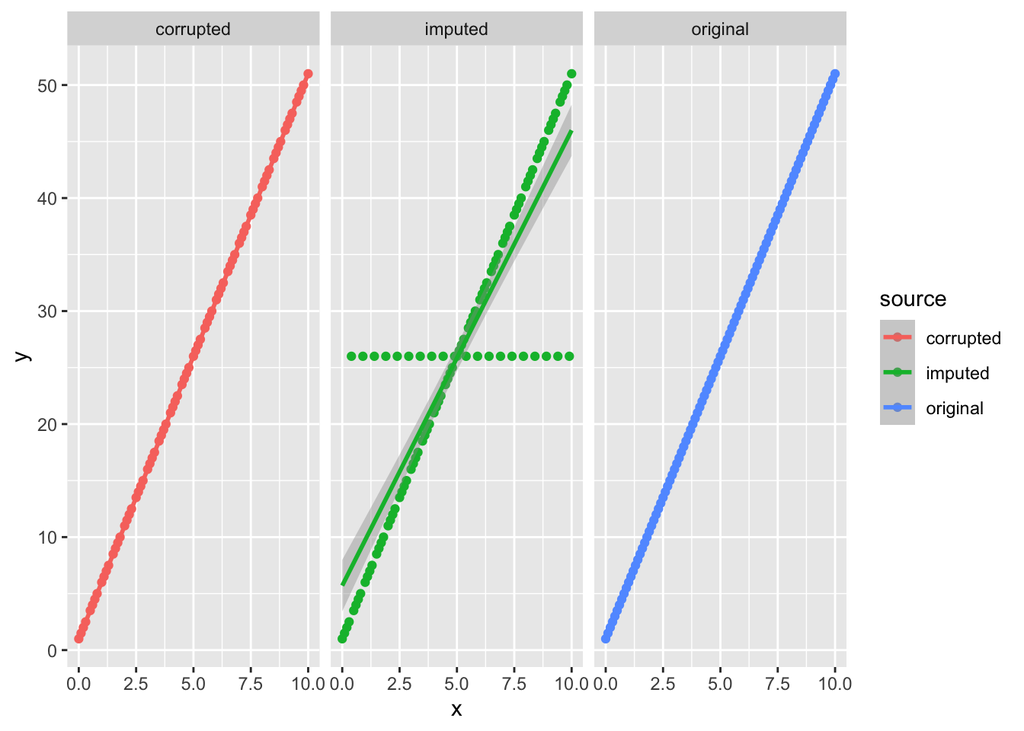

```r
df_xy<-df_xy %>% mutate(source="original")
df_xy_missing<-df_xy_missing %>% mutate(source="corrupted")
df_xy_imputed<-df_xy_imputed %>% mutate(source="imputed")
df_combined<-rbind(df_xy,df_xy_missing,df_xy_imputed)

ggplot(df_combined, aes(x=x,y=y,colour=source)) + geom_point() + facet_wrap(~source) + geom_smooth(method = "lm")
```

#### 2.2 Tidying data with pivot functions

```r
library(readxl)
folder_path <- "/Users/maxkirwan/Desktop/Uni/Data Science MSc/SCEM/Statistical-Computing-and-Empirical-Methods"
file_name <- "HockeyLeague.xlsx"
file_path <- paste(folder_path,file_name,sep="/")
wins_df <- read_excel(file_path,sheet="Wins")
```

```
## * `` -> ...1
```

```r
wins_df %>%
  select(1:5) %>%
  head(3)
```

```
## # A tibble: 3 × 5
##   ...1   `1990`   `1991`   `1992`   `1993`
##   <chr>  <chr>    <chr>    <chr>    <chr>
## 1 Ducks  30 of 50 11 of 50 30 of 50 12 of 50
## 2 Eagles 24 of 50 12 of 50 37 of 50 14 of 50
## 3 Hawks  20 of 50 22 of 50 33 of 50 11 of 50
```

```r
wins_tidy <- wins_df %>%
  rename(Team=1) %>%
  pivot_longer(!Team, names_to="Year", values_to="Wins") %>%
  separate(Wins, c("Wins","Total"), sep=" of ", convert=TRUE)
wins_tidy %>% dim() # check the dimensions
```

```
## [1] 248   4
```

```r
wins_tidy %>% head(5) # inspect the top 5 rows
```

```
## # A tibble: 5 × 4
##   Team  Year   Wins Total
##   <chr> <chr> <int> <int>
## 1 Ducks 1990     30    50
## 2 Ducks 1991     11    50
## 3 Ducks 1992     30    50
## 4 Ducks 1993     12    50
## 5 Ducks 1994     24    50
```

```r
losses_df <- read_excel(file_path,sheet="Losses")
```

```
## * `` -> ...1
```

```r
losses_tidy <- losses_df %>%
  rename(Team=1) %>%
  pivot_longer(!Team, names_to="Year", values_to="Losses") %>%
  separate(Losses, c("Losses","Total"), sep=" of ", convert=TRUE)
losses_tidy %>% head(5)
```

```
## # A tibble: 5 × 4
##   Team  Year  Losses Total
##   <chr> <chr>  <int> <int>
## 1 Ducks 1990      20    50
## 2 Ducks 1991      37    50
## 3 Ducks 1992       1    50
## 4 Ducks 1993      30    50
## 5 Ducks 1994       7    50
```

```r
# Joining wins and losses data frames
hockey_df <- wins_tidy %>%
  inner_join(losses_tidy, by=c("Team","Year","Total")) %>%
  mutate(Draws = Total - (Wins + Losses), Wins_ratio = Wins / Total, Losses_ratio = Losses / Total, Draws_ratio = Draws / Total)
hockey_df %>% head(5)
```

```
## # A tibble: 5 × 9
##   Team  Year   Wins Total Losses Draws Wins_ratio Losses_ratio Draws_ratio
##   <chr> <chr> <int> <int>  <int> <int>      <dbl>        <dbl>       <dbl>
## 1 Ducks 1990     30    50     20     0       0.6          0.4         0
## 2 Ducks 1991     11    50     37     2       0.22         0.74        0.04
## 3 Ducks 1992     30    50      1    19       0.6          0.02        0.38
## 4 Ducks 1993     12    50     30     8       0.24         0.6         0.16
## 5 Ducks 1994     24    50      7    19       0.48         0.14        0.38
```

```r
# Summary data frame
hockey_df %>%
  group_by(Team) %>%
  summarise(median_win_rate=median(Wins_ratio,na.rm=1), mean_win_rate=mean(Wins_ratio,na.rm=1), median_loss_rate=median(Losses_ratio,na.rm=1), mean_loss_rate=mean(Losses_ratio,na.rm=1), median_draw_rate=median(Draws_ratio,na.rm=1), mean_draw_rate=mean(Draws_ratio,na.rm=1)) %>%
  arrange(desc(median_win_rate))
```

```
## # A tibble: 8 × 7
##   Team        median_win_rate mean_win_rate median_loss_rate mean_loss_rate
##   <chr>                 <dbl>         <dbl>            <dbl>          <dbl>
## 1 Eagles                0.45          0.437            0.25           0.279
## 2 Penguins              0.45          0.457            0.3            0.310
## 3 Hawks                 0.417         0.388            0.233          0.246
## 4 Ducks                 0.383         0.362            0.34           0.333
## 5 Owls                  0.32          0.333            0.3            0.33
## 6 Ostriches             0.3           0.309            0.4            0.395
## 7 Storks                0.3           0.284            0.22           0.283
## 8 Kingfishers           0.233         0.245            0.34           0.360
## # … with 2 more variables: median_draw_rate <dbl>, mean_draw_rate <dbl>
```

#### 2.3 Most correlated variables

```r
max_cor_var<-function(df,col_name){
# function to determine the variable with maximal correlation
v_col <- df %>% select(all_of(col_name)) # extract variable based on col_name
df_num <- df %>% select_if(is.numeric) %>% select(-all_of(col_name))
# select all numeric variables excluding col_name
correlations <- unlist(map(df_num, function(x){cor(x,v_col,use="complete.obs")}))
  # compute correlations with all other numeric variables
max_abs_cor_var <- names(which(abs(correlations)==max(abs(correlations)))) # extract the variable name
cor <- as.double(correlations[max_abs_cor_var])
# compute the correlation
return(data.frame(var_name=max_abs_cor_var,cor=cor))
  # return dataframe
}
library(palmerpenguins)
max_cor_var(penguins, "bill_length_mm")
```

```
##            var_name       cor
## 1 flipper_length_mm 0.6561813
```

## 3. Elementary set theory

#### 3.1 Rolling a dice

Suppose we roll a dice. Then the set of possible outcomes is $\Omega := \{1,2,3,4,5,6\}$.

Define events $A := \{1,2,3\}$, $B := \{2,4,6\}$ and $C := \{4,5,6\}$.

Then we have:

- $A \cup B = \{1,2,3,4,6\}$
- $A \cup C = \Omega$
- $A \cap B = \{2\}$
- $A \cap C = \emptyset$
- $A \setminus B = \{1,3\}$
- $A \setminus C = \{1,2,3\}$
- A and B are not disjoint
- A and C are disjoint
- $\{1,2,3,6\},\{4,5\}$ and $\{1\},\{2,3,4\},\{5,6\}$ are both partitions of $\Omega$

#### 3.2 Complements, subsets and De Morgan’s laws

Let $\Omega$ be a sample space and let $A,B \subseteq \Omega$ be events.

- $(A^c)^c = A$
- $\Omega ^c = \emptyset$
- $A \subseteq B \implies A \cup B = B \implies (A \cup B)^c = B^c \implies A^c \cap B^c = B^c \implies B^c \subseteq A^c$

#### 3.3 Cardinality and the set of all subsets

Let $\Omega$ be a sample space with $K$ elements.

Let $\mathcal{E}:= \{A \subseteq \Omega \}$ be the set of all subsets.

## 4. Introduction to probability

#### 4.1 Probability of a complement

Let $\Omega$ be a sample space and $S \subseteq \Omega$ an event.

Then since $S$ and $S^c$ are disjoint, we have $\mathbb{P}(S \cup S^c) = \mathbb{P}(S) + \mathbb{P}(S^c) \implies \mathbb{P}(\Omega) = \mathbb{P}(S) + \mathbb{P}(S^c) \implies \mathbb{P}(S^c) = 1 - \mathbb{P}(S)$.

#### 4.2 The union bound

Let $A,B \subseteq \Omega$ be events with $A\subset B$ and $\mathbb{P}(A)>0$.

Then $\mathbb{P}(A\cup B) = \mathbb{P}(B) \neq \mathbb{P}(A) + \mathbb{P}(B)$.